https://aleksatodorovic.github.io/index.html

# Milestone 2 - SIPRI arms transfers data ETL

### Alex Todorovic - Sources:

http://www.sipri.org/databases/armstransfers/armstransfers

http://www.sipri.org/databases/armstransfers/armstransfers/background#Coverage

http://www.sipri.org/databases

https://gist.github.com/jsvine/9cb3300588ed402160fe <- Link to data retrieval. It's just a simple curl command.

### Extraction

```python
import pandas as pd
import matplotlib.pyplot as plt
from matplotlib.pyplot import *
import seaborn as sns
```

### As I mentioned, the dataset is retrievable by a curl command that some dude was kind enough to provide. I've included the link up there ^^ with a little note. For simplicity I've just read it in as a csv file here.

```python
arms = pd.read_csv("sipri-by-seller-1950-2014.csv")
arms.head()
```

|  | id | buyercode | sellercode | order_year | odai | ordered | onai | delivery_year | term | designation | ... | coprod | nrdel | nrdelai | delyears | buyer | seller | status | tivunit | tivorder | tivdel |
| --- | --- | --- | --- | --- | --- | --- | --- | --- | --- | --- | --- | --- | --- | --- | --- | --- | --- | --- | --- | --- | --- |
| 0 | 55238.0 | BF | ALB | 2011.0 | X | 12.0 | X | 2011.0 | NaN | M-43 120mm | ... | L | 12.0 | NaN | 2011 | Burkina Faso | Albania | S | 0.020 | 0.240 | 0.240 |
| 1 | 3622.0 | ANG | ALG | 1980.0 | NaN | 4.0 | NaN | 1980.0 | NaN | N-262 Fregate | ... | L | 4.0 | NaN | 1980 | Angola | Algeria | S | 1.500 | 6.000 | 6.000 |
| 2 | 11246.0 | NIG | ALG | 1967.0 | NaN | 2.0 | X | 1968.0 | NaN | Il-28 | ... | L | 2.0 | X | 1968 | Nigeria | Algeria | S | 2.880 | 5.760 | 5.760 |
| 3 | 3667.0 | CON | ANG | 1979.0 | NaN | 1.0 | NaN | 1979.0 | AID | Noratlas | ... | L | 1.0 | NaN | 1979 | Congo | Angola | S | 2.800 | 2.800 | 2.800 |
| 4 | 3684.0 | GBI | ANG | 1980.0 | NaN | 1.0 | NaN | 1980.0 | NaN | Do-27 | ... | L | 1.0 | NaN | 1980 | Guinea-Bissau | Angola | S | 0.048 | 0.048 | 0.048 |

5 rows × 22 columns

```python
arms.shape
```

```
(24078, 22)
```

That's a lot of data :)

```python
arms.dtypes
```

```
id               float64
buyercode         object
sellercode        object
order_year       float64
odai              object
ordered          float64
onai              object
delivery_year    float64
term              object
designation       object
category          object
desc              object
coprod            object
nrdel            float64
nrdelai           object
delyears          object
buyer             object
seller            object
status            object
tivunit          float64
tivorder         float64
tivdel           float64
dtype: object
```

### I figured I'd be doing a lot of line plotting, specifically of just arms deals by buyer/seller over a time span so I've included these two functions as baby steps towards automating some visualizations/analyses.

```python
def plot_sellers(countries): #input should be a list
    fig, ax = subplots(figsize=(20,10))
    for x in countries:
        arms.loc[(arms['order_year']>1949) & (arms['seller']==x)]['order_year'].groupby(arms.order_year).agg('count').plot(kind='line',ax=ax)
    plt.suptitle('Arms Transfers by Seller', x=0.5, y=0.95, ha='center', fontsize='xx-large')
    fig.text(0.5, 0.04, 'Year', ha='center')
    fig.text(0.09, 0.5, 'Arms Deals', va='center', rotation='vertical')
    ax.legend(countries)
    return ax

def plot_buyers(countries): #input should be a list
    fig, ax = subplots(figsize=(20,10))
    for x in countries:
        arms.loc[(arms['order_year']>1949) & (arms['buyer']==x)]['order_year'].groupby(arms.order_year).agg('count').plot(kind='line',ax=ax)
    plt.suptitle('Arms Transfers by Buyer', x=0.5, y=0.95, ha='center', fontsize='xx-large')
    fig.text(0.5, 0.04, 'Year', ha='center')
    fig.text(0.09, 0.5, 'Arms Deals', va='center', rotation='vertical')
    ax.legend(countries)
    return ax
```

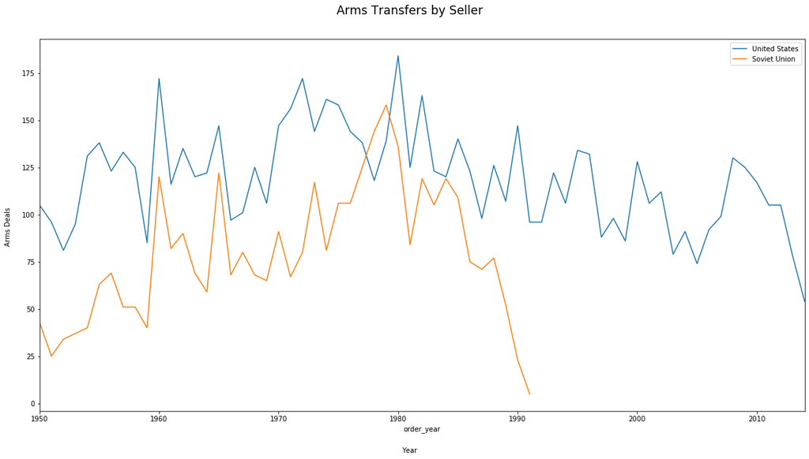

```python
ax = plot_sellers(["United States","Soviet Union"])
```

This graph is essentially a story of the cold war up to the breakup of the Soviet Union in 1991. Moving forward I'd like to annotate these graphs so as to contextualize increases/decreases, show a country's arms exports by year broken down by buyer, and hypothesize which sphere of influence a country belongs to or controls depending on who they're selling weapons to or buying weapons from.

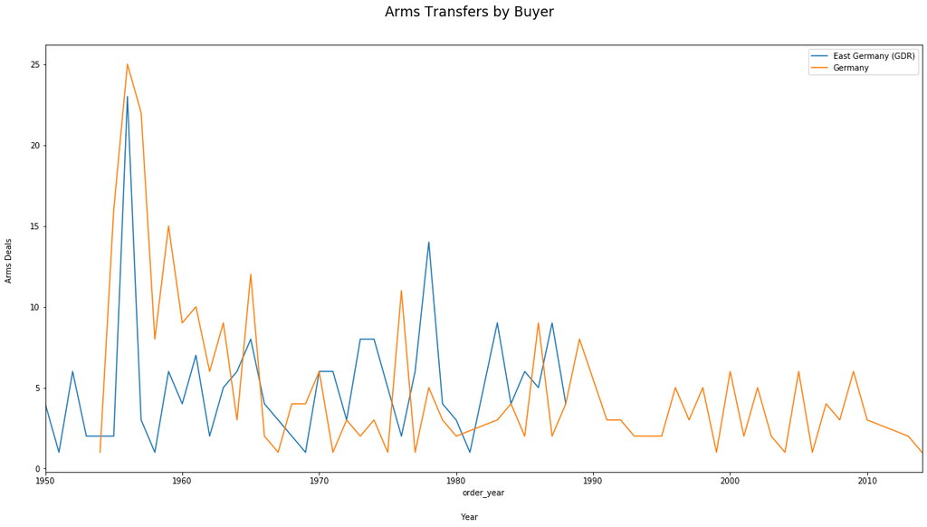

```python
plot_buyers(["East Germany (GDR)", "Germany"])
```

Out of curiosity let's see who the Soviet Union's biggest clients were in 1978. These are countries with more than 4 arms deals in that single year.

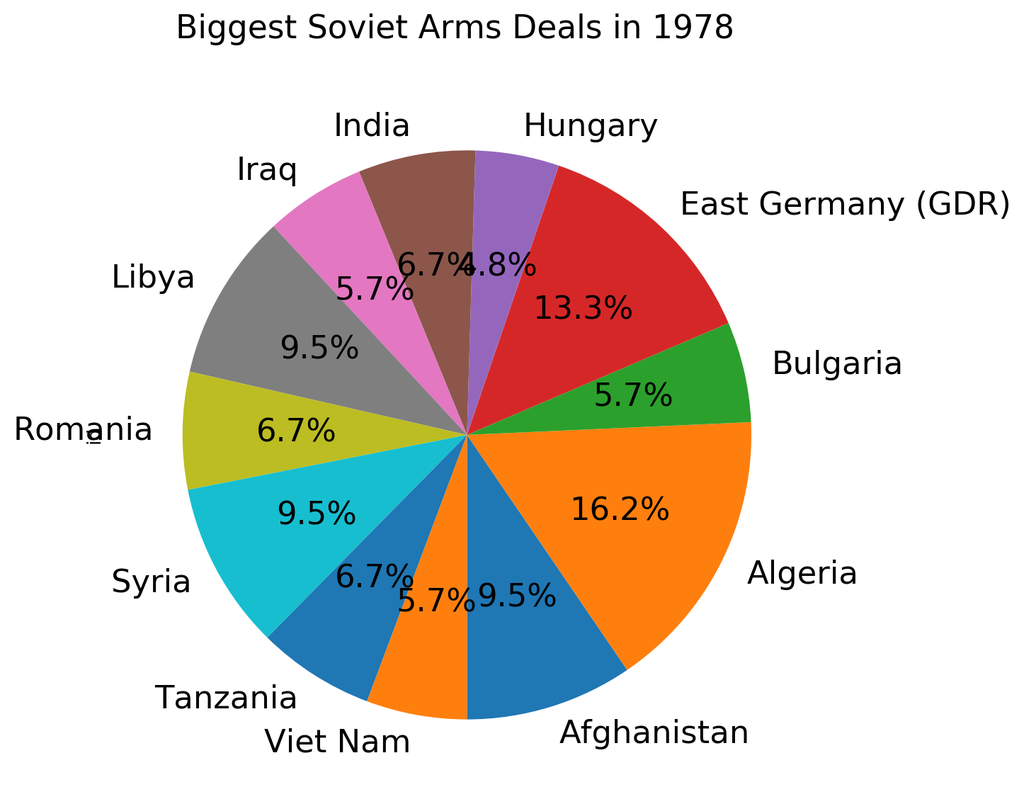

```python
ussr = arms.loc[(arms.seller=="Soviet Union") & (arms.order_year==1978)]

counts = ussr.groupby(ussr.buyer).agg('count')
#counts.loc[counts.id>7].plot.pie(y='id',figsize=(10,10),legend='lower right')


fig = plt.figure(figsize=(7,7), dpi=190)
ax = plt.subplot(111)
plt.suptitle('Biggest Soviet Arms Deals in 1978', x=0.5, y=0.95, ha='center', fontsize='xx-large')
counts.loc[counts.id>4].id.plot(kind='pie', ax=ax, autopct='%1.1f%%', startangle=270, fontsize=17)
```